# statistical analysis

Objective: Exploring the trends and factors related to suicide rates across different countries, years, genders, and age groups.

#Loading data

```r
library(tidyverse)
```

```r
library(gganimate)
library(ggplot2)
library(tidyr)
data<-read.csv("who_suicide_statistics.csv")
str(data)
```

```
## 'data.frame':    43776 obs. of  6 variables:
##  $ country    : chr  "Albania" "Albania" "Albania" "Albania" ...
##  $ year       : int  1985 1985 1985 1985 1985 1985 1985 1985 1985 1985 ...
##  $ sex        : chr  "female" "female" "female" "female" ...
##  $ age        : chr  "15-24 years" "25-34 years" "35-54 years" "5-14 years" ...
##  $ suicides_no: int  NA NA NA NA NA NA NA NA NA NA ...
##  $ population : int  277900 246800 267500 298300 138700 34200 301400 264200 296700 325800 ...
```

```r
summary(data)
```

```
##    country               year          sex                age
##  Length:43776       Min.   :1979   Length:43776       Length:43776
##  Class :character   1st Qu.:1990   Class :character   Class :character
##  Mode  :character   Median :1999   Mode  :character   Mode  :character
##                     Mean   :1999
##                     3rd Qu.:2007
##                     Max.   :2016
##
##   suicides_no        population
##  Min.   :    0.0   Min.   :     259
##  1st Qu.:    1.0   1st Qu.:   85113
##  Median :   14.0   Median :  380655
##  Mean   :  193.3   Mean   : 1664091
##  3rd Qu.:   91.0   3rd Qu.: 1305698
##  Max.   :22338.0   Max.   :43805214
##  NA's   :2256      NA's   :5460
```

## Handling null values

```r
# imputing data
data_imputed <- replace_na(data, list(suicides_no = 0,population=0))
```

# Descriptive statistics

```r
# Summary statistics of suicide numbers and population grouped by country
summary_stats <- data_imputed %>%
  group_by(country) %>%
  summarize(
    mean_suicides = mean(suicides_no),
    mean_population = mean(population)
  )

# Displaying summary statistics
head(summary_stats)
```

| country | mean_suicides | mean_population |
| --- | --- | --- |
| Albania | 5.295699e+00 | 233851.376 |
| Anguilla | 5.747126e-03 | 0.000 |
| Antigua and Barbuda | 3.273810e-02 | 6115.830 |
| Argentina | 2.114009e+02 | 2680715.610 |
| Armenia | 5.766667e+00 | 254150.421 |
| Aruba | 5.000000e-01 | 7341.854 |

```r
# Summary statistics of suicide numbers and population grouped by year
summary_stats <- data_imputed %>%
  group_by(year) %>%
  summarize(
    mean_suicides = mean(suicides_no),
    mean_population = mean(population)
  )

# Displaying summary statistics
head(summary_stats)
```

| year | mean_suicides | mean_population |
| --- | --- | --- |
| 1979 | 138.0804 | 1464536 |
| 1980 | 190.9801 | 1517531 |
| 1981 | 178.7289 | 1315661 |
| 1982 | 195.3985 | 1363733 |
| 1983 | 129.1456 | 1406723 |
| 1984 | 148.1274 | 1449572 |

```r
# Summary statistics of suicide numbers and population grouped by age
summary_stats <- data_imputed %>%
  group_by(age) %>%
  summarize(
    mean_suicides = mean(suicides_no),
    mean_population = mean(population)
  )

# Displaying summary statistics
head(summary_stats)
```

| age | mean_suicides | mean_population |
| --- | --- | --- |
| 15-24 years | 134.907758 | 1512610.9 |
| 25-34 years | 187.408580 | 1451498.0 |
| 35-54 years | 396.845943 | 2392497.1 |
| 5-14 years | 8.677632 | 1496099.2 |
| 55-74 years | 268.430373 | 1459856.0 |
| 75+ years | 103.846902 | 426654.2 |

```r
# Summary statistics of suicide numbers and population grouped by sex
summary_stats <- data_imputed %>%
  group_by(sex) %>%
  summarize(
    mean_suicides = mean(suicides_no),
    mean_population = mean(population)
  )

# Displaying summary statistics
head(summary_stats)
```

| sex | mean_suicides | mean_population |
| --- | --- | --- |
| female | 86.90936 | 1490781 |
| male | 279.79637 | 1422291 |

# Exploratory Data analysis

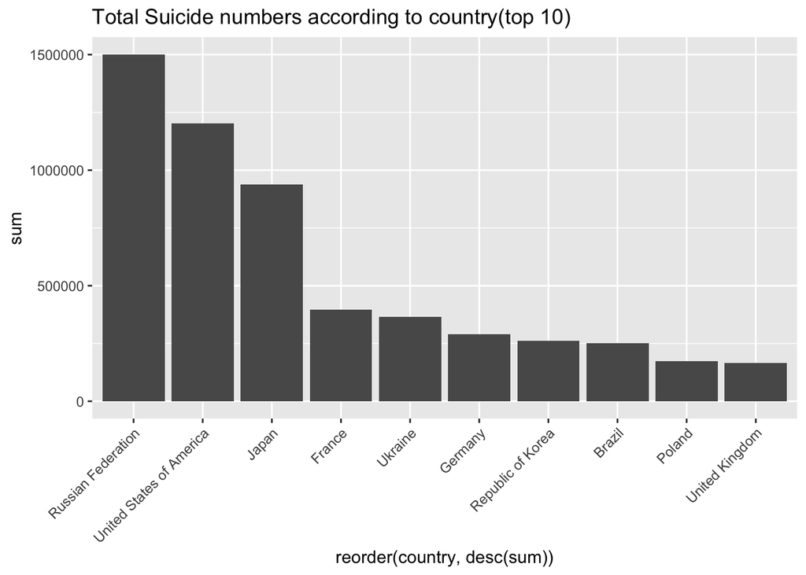

```r
data_imputed%>%
  group_by(country)%>%
  summarise(sum=sum(suicides_no))%>%
  slice_max(sum,n=10)%>%
  ggplot(aes(x=reorder(country,desc(sum)),y=sum))+geom_col()+labs(title="Total Suicide numbers according to country(top 10)")+theme(axis.text.x = element_text(angle = 45, hjust = 1))
```

```r
new<-data_imputed%>%
  # selecting required columns
  select(year,age,suicides_no)%>%
  group_by(year,age)%>%
  summarize(sum=sum(suicides_no))
```

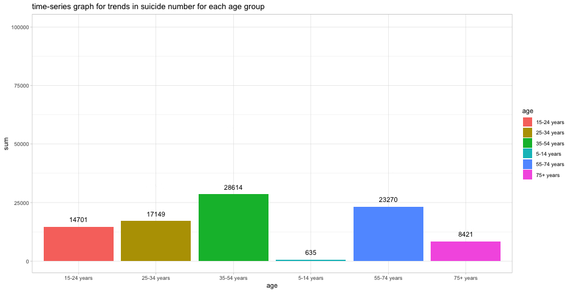

```r
# creating a ggplot
a <- ggplot(new, aes(x =age,y = sum,fill=age)) +
  geom_bar(stat = "identity") +
  labs(title = "Year: {closest_state}") +
  geom_text(aes(label = sum),
            position = position_dodge(0.9), vjust = -1 ) +
  ylim(0,100500)+
  theme_light()+
  transition_states(states = year, transition_length = 10000000000000, state_length = 1000000000000000) +
  enter_fade() +
  exit_shrink() +
  ease_aes('quadratic-in-out')+labs(title="time-series graph for trends in suicide number for each age group")
# gif
a_gif <- animate(a, width = 940, height = 480)

a_gif
```

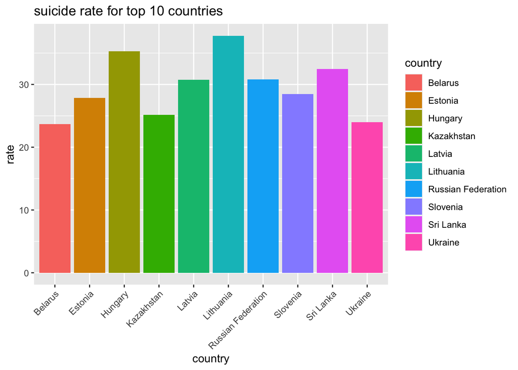

```r
data_imputed %>%
  # filtering data
  filter(population != 0) %>%
  select(country, suicides_no, population,year) %>%
  group_by(country) %>%
  summarise(s = sum(suicides_no), p = sum(population))%>%
  mutate(rate=s/p*100000)%>%
  slice_max(rate,n=10)%>%
  # creating plot
  ggplot(aes(x=country,y=rate,fill=country))+geom_col()+labs(title="suicide rate for top 10 countries")+theme(axis.text.x = element_text(angle = 45, hjust = 1))
```

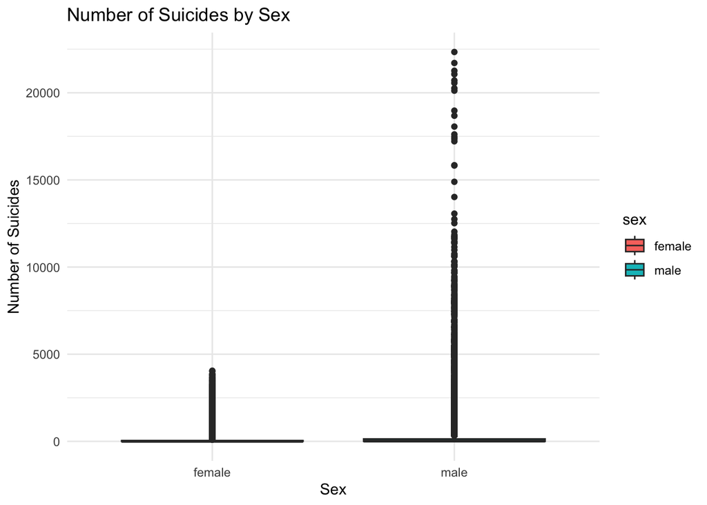

```r
# Boxplot of suicides_no by sex
ggplot(data_imputed, aes(x = sex, y = suicides_no, fill = sex)) +
  geom_boxplot() +
  labs(title = "Number of Suicides by Sex", x = "Sex", y = "Number of Suicides") +
  theme_minimal()
```

# Regression analysis

```r
lm_model <- lm(suicides_no ~ year + sex + age, data = data_imputed)

# Summarizing the regression model
summary(lm_model)
```

```
##
## Call:
## lm(formula = suicides_no ~ year + sex + age, data = data_imputed)
##
## Residuals:
##     Min      1Q  Median      3Q     Max
##  -493.5  -216.2   -99.1     3.4 21844.7
##
## Coefficients:
##                  Estimate Std. Error t value Pr(>|t|)
## (Intercept)      61.21398  706.83205   0.087   0.9310
## year             -0.01138    0.35365  -0.032   0.9743
## sexmale         192.88702    7.31244  26.378  < 2e-16 ***
## age25-34 years   52.50082   12.66552   4.145  3.4e-05 ***
## age35-54 years  261.93819   12.66552  20.681  < 2e-16 ***
## age5-14 years  -126.23013   12.66552  -9.966  < 2e-16 ***
## age55-74 years  133.52262   12.66552  10.542  < 2e-16 ***
## age75+ years    -31.06086   12.66552  -2.452   0.0142 *
## ---
## Signif. codes:  0 '***' 0.001 '**' 0.01 '*' 0.05 '.' 0.1 ' ' 1
##
## Residual standard error: 765 on 43768 degrees of freedom
## Multiple R-squared:  0.04041,    Adjusted R-squared:  0.04025
## F-statistic: 263.3 on 7 and 43768 DF,  p-value: < 2.2e-16
```

> The coefficients indicate the estimated effect of each predictor variable on the number of suicides. For example, being male (sexmale) is associated with an increase of 192.89 in the number of suicides compared to being female. A p-value less than 0.05 (commonly used threshold) suggests that the variable has a significant effect on the number of suicides. The adjusted R-squared value (0.04025) indicates that the model explains about 4.025% of the variance in the number of suicides, suggesting that the model might not be a good fit for the data.

> The regression model suggests that variables such as sex and age group have a significant impact on the number of suicides, while the year variable and the intercept may not be statistically significant predictors.

# ANOVA analysis

```r
# Fitting ANOVA model
anova_model <- aov(suicides_no ~ sex, data = data_imputed)

# Summarizing ANOVA results
summary(anova_model)
```

```
##                Df    Sum Sq   Mean Sq F value Pr(>F)
## sex             1 4.072e+08 407175907   678.1 <2e-16 ***
## Residuals   43774 2.628e+10    600451
## ---
## Signif. codes:  0 '***' 0.001 '**' 0.01 '*' 0.05 '.' 0.1 ' ' 1
```

> The ANOVA results indicate that there is a significant difference in the mean number of suicidesbetween males and females. The F-value is 678.1, and the p-value is less than 2e-16, which is highly significant.